# Import modules

```python
import pandas as pd
import numpy as np
import seaborn as sns
import matplotlib.pyplot as plt
import warnings
from termcolor import colored

from sklearn.preprocessing import MinMaxScaler
from sklearn.model_selection import train_test_split, GridSearchCV, cross_val_score, KFold
from sklearn.ensemble import RandomForestClassifier
from sklearn import metrics
from sklearn.linear_model import LogisticRegression
from sklearn.svm import SVC
from sklearn.tree import DecisionTreeClassifier
from sklearn.neighbors import KNeighborsClassifier
from sklearn.naive_bayes import GaussianNB

import warnings
warnings.filterwarnings("ignore")

print(colored('\nAll libraries imported succesfully.'))
```

```
All libraries imported succesfully.
```

# Loading Dataset

```python
df = pd.read_csv('Cardiovascular_Disease_Dataset.csv')
```

```python
df.head()
```

|  | patientid | age | gender | chestpain | restingBP | serumcholestrol | fastingbloodsugar | restingrelectro | maxheartrate | exerciseangia | oldpeak | slope | noofmajorvessels | target |
| --- | --- | --- | --- | --- | --- | --- | --- | --- | --- | --- | --- | --- | --- | --- |
| 0 | 103368 | 53 | 1 | 2 | 171 | 0 | 0 | 1 | 147 | 0 | 5.3 | 3 | 3 | 1 |
| 1 | 119250 | 40 | 1 | 0 | 94 | 229 | 0 | 1 | 115 | 0 | 3.7 | 1 | 1 | 0 |
| 2 | 119372 | 49 | 1 | 2 | 133 | 142 | 0 | 0 | 202 | 1 | 5.0 | 1 | 0 | 0 |
| 3 | 132514 | 43 | 1 | 0 | 138 | 295 | 1 | 1 | 153 | 0 | 3.2 | 2 | 2 | 1 |
| 4 | 146211 | 31 | 1 | 1 | 199 | 0 | 0 | 2 | 136 | 0 | 5.3 | 3 | 2 | 1 |

# Data Information

```python
df.info()
```

```
<class 'pandas.core.frame.DataFrame'>
RangeIndex: 1000 entries, 0 to 999
Data columns (total 14 columns):
 #   Column             Non-Null Count  Dtype
---  ------             --------------  -----
 0   patientid          1000 non-null   int64
 1   age                1000 non-null   int64
 2   gender             1000 non-null   int64
 3   chestpain          1000 non-null   int64
 4   restingBP          1000 non-null   int64
 5   serumcholestrol    1000 non-null   int64
 6   fastingbloodsugar  1000 non-null   int64
 7   restingrelectro    1000 non-null   int64
 8   maxheartrate       1000 non-null   int64
 9   exerciseangia      1000 non-null   int64
 10  oldpeak            1000 non-null   float64
 11  slope              1000 non-null   int64
 12  noofmajorvessels   1000 non-null   int64
 13  target             1000 non-null   int64
dtypes: float64(1), int64(13)
memory usage: 109.5 KB
```

```python
df.describe().T.style.background_gradient(axis=0)
```

|  | count | mean | std | min | 25% | 50% | 75% | max |
| --- | --- | --- | --- | --- | --- | --- | --- | --- |
| patientid | 1000.000000 | 5048704.412000 | 2895904.500488 | 103368.000000 | 2536439.500000 | 4952508.500000 | 7681877.000000 | 9990855.000000 |
| age | 1000.000000 | 49.242000 | 17.864730 | 20.000000 | 34.000000 | 49.000000 | 64.250000 | 80.000000 |
| gender | 1000.000000 | 0.765000 | 0.424211 | 0.000000 | 1.000000 | 1.000000 | 1.000000 | 1.000000 |
| chestpain | 1000.000000 | 0.980000 | 0.953157 | 0.000000 | 0.000000 | 1.000000 | 2.000000 | 3.000000 |
| restingBP | 1000.000000 | 151.747000 | 29.965228 | 94.000000 | 129.000000 | 147.000000 | 181.000000 | 200.000000 |
| serumcholestrol | 1000.000000 | 311.447000 | 132.443801 | 0.000000 | 235.750000 | 318.000000 | 404.250000 | 602.000000 |
| fastingbloodsugar | 1000.000000 | 0.296000 | 0.456719 | 0.000000 | 0.000000 | 0.000000 | 1.000000 | 1.000000 |
| restingrelectro | 1000.000000 | 0.748000 | 0.770123 | 0.000000 | 0.000000 | 1.000000 | 1.000000 | 2.000000 |
| maxheartrate | 1000.000000 | 145.477000 | 34.190268 | 71.000000 | 119.750000 | 146.000000 | 175.000000 | 202.000000 |
| exerciseangia | 1000.000000 | 0.498000 | 0.500246 | 0.000000 | 0.000000 | 0.000000 | 1.000000 | 1.000000 |
| oldpeak | 1000.000000 | 2.707700 | 1.720753 | 0.000000 | 1.300000 | 2.400000 | 4.100000 | 6.200000 |
| slope | 1000.000000 | 1.540000 | 1.003697 | 0.000000 | 1.000000 | 2.000000 | 2.000000 | 3.000000 |
| noofmajorvessels | 1000.000000 | 1.222000 | 0.977585 | 0.000000 | 0.000000 | 1.000000 | 2.000000 | 3.000000 |
| target | 1000.000000 | 0.580000 | 0.493805 | 0.000000 | 0.000000 | 1.000000 | 1.000000 | 1.000000 |

# Data Cleaning and Preprocessing Steps

1. Handling missing values
2. Converting data types
3. Handling outliers
4. Encoding categorical variables (Nominal and Binary)
5. Feature scaling (Normalization/Standardization)
6. Removing duplicates

## Handling missing values

**Conclusion:** The output indicates that there are no missing values (0 missing values) for all columns in this dataset. This is a good sign because it means that there are no null or NaN values that need to be handled during preprocessing.

```python
df.isna().sum()
```

```
patientid            0
age                  0
gender               0
chestpain            0
restingBP            0
serumcholestrol      0
fastingbloodsugar    0
restingrelectro      0
maxheartrate         0
exerciseangia        0
oldpeak              0
slope                0
noofmajorvessels     0
target               0
dtype: int64
```

## Checking Data type of each column

**Conclusion:**

1. Columns like gender, fastingbloodsugar, exerciseangia, and target are binary features that could be better represented as categorical data.
2. Columns like chestpain, restingrelectro, and slope are nominal features and should also be converted to categorical type (category dtype) to save memory and improve processing speed.

```python
df.dtypes
```

```
patientid              int64
age                    int64
gender                 int64
chestpain              int64
restingBP              int64
serumcholestrol        int64
fastingbloodsugar      int64
restingrelectro        int64
maxheartrate           int64
exerciseangia          int64
oldpeak              float64
slope                  int64
noofmajorvessels       int64
target                 int64
dtype: object
```

## Data Type Conversion

**Why Convert to Category Type?**

1. Memory Efficiency: The category dtype reduces memory usage when there are many repeated values in categorical columns, which is typical for binary and nominal features.
2. Faster Computations: Operations on categorical data can be faster since they are stored as integer codes internally rather than as strings.

```python
# Convert binary columns to categorical type
binary_cols = ['gender', 'fastingbloodsugar', 'exerciseangia', 'target']
df[binary_cols] = df[binary_cols].astype('category')

# Convert nominal columns to categorical type
nominal_cols = ['chestpain', 'restingrelectro', 'slope']
df[nominal_cols] = df[nominal_cols].astype('category')

# Check the updated data types
print(df.dtypes)
```

```
patientid               int64
age                     int64
gender               category
chestpain            category
restingBP               int64
serumcholestrol         int64
fastingbloodsugar    category
restingrelectro      category
maxheartrate            int64
exerciseangia        category
oldpeak               float64
slope                category
noofmajorvessels        int64
target               category
dtype: object
```

## Handling Duplicated values

**Conclusion:** No duplicate values found

```python
df.duplicated().sum
```

```
<bound method Series.sum of 0      False
1      False
2      False
3      False
4      False
       ...
995    False
996    False
997    False
998    False
999    False
Length: 1000, dtype: bool>
```

```python
# Remove duplicates
df.drop_duplicates(inplace=True)
```

```python
df.shape
```

```
(1000, 14)
```

## Handling Outliers

**Conclusion:**

1. No Outliers Detected: Both methods (IQR and Z-Score) show that there are no outliers in the numeric columns of the dataset. This indicates that the data points in the numeric features such as age, restingBP, serumcholestrol, maxheartrate, oldpeak, and noofmajorvessels fall within the expected range and there are no extreme values that deviate significantly from the rest of the data.
2. This is good for analysis and model-building, as outliers can sometimes skew the results of statistical tests and machine learning algorithms.

### 1. Outlier Detection Using IQR

```python
# Define a function to detect outliers using IQR
def detect_outliers_iqr(df):
    outliers = {}
    for col in df.select_dtypes(include=['float64', 'int64']).columns:
        Q1 = df[col].quantile(0.25)
        Q3 = df[col].quantile(0.75)
        IQR = Q3 - Q1
        lower_bound = Q1 - 1.5 * IQR
        upper_bound = Q3 + 1.5 * IQR
        outliers[col] = df[(df[col] < lower_bound) | (df[col] > upper_bound)].shape[0]  # Count of outliers
    return outliers

# Check for outliers in each numeric column using IQR
outliers_iqr = detect_outliers_iqr(df)
print("Outliers based on IQR:", outliers_iqr)
```

```
Outliers based on IQR: {'patientid': 0, 'age': 0, 'restingBP': 0, 'serumcholestrol': 0, 'maxheartrate': 0, 'oldpeak': 0, 'noofmajorvessels': 0}
```

### 2. Outlier Detection Using Z-Score

```python
from scipy.stats import zscore

# Define a function to detect outliers using Z-Score
def detect_outliers_zscore(df):
    outliers = {}
    for col in df.select_dtypes(include=['float64', 'int64']).columns:
        z_scores = zscore(df[col].dropna())  # Remove NaN before calculating Z-score
        outliers[col] = (abs(z_scores) > 3).sum()  # Count of outliers (Z-score > 3 or < -3)
    return outliers

# Check for outliers in each numeric column using Z-Score
outliers_zscore = detect_outliers_zscore(df)
print("Outliers based on Z-Score:", outliers_zscore)
```

```
Outliers based on Z-Score: {'patientid': 0, 'age': 0, 'restingBP': 0, 'serumcholestrol': 0, 'maxheartrate': 0, 'oldpeak': 0, 'noofmajorvessels': 0}
```

## Encode categorical variables

```python
from sklearn.preprocessing import StandardScaler, LabelEncoder

# Label Encoding for Binary columns (Gender, Fasting Blood Sugar, Exercise Angina, Target)
binary_cols = ['gender', 'fastingbloodsugar', 'exerciseangia', 'target']
label_encoder = LabelEncoder()

for col in binary_cols:
    df[col] = label_encoder.fit_transform(df[col])
```

```python
df.columns
```

```
Index(['patientid', 'age', 'gender', 'chestpain', 'restingBP',
       'serumcholestrol', 'fastingbloodsugar', 'restingrelectro',
       'maxheartrate', 'exerciseangia', 'oldpeak', 'slope', 'noofmajorvessels',
       'target'],
      dtype='object')
```

```python
# One-Hot Encoding for Nominal columns (Chest Pain, Resting Electrocardiogram, Slope)
df = pd.get_dummies(df, columns=['chestpain', 'restingrelectro', 'slope'], drop_first=False)
```

```python
df.columns
```

```
Index(['patientid', 'age', 'gender', 'restingBP', 'serumcholestrol',
       'fastingbloodsugar', 'maxheartrate', 'exerciseangia', 'oldpeak',
       'noofmajorvessels', 'target', 'chestpain_0', 'chestpain_1',
       'chestpain_2', 'chestpain_3', 'restingrelectro_0', 'restingrelectro_1',
       'restingrelectro_2', 'slope_0', 'slope_1', 'slope_2', 'slope_3'],
      dtype='object')
```

## Feature Scaling

```python
# Min-Max Scaling
from sklearn.preprocessing import MinMaxScaler

# Initialize the Min-Max scaler
scaler = MinMaxScaler()

# List of numeric columns
numeric_cols = ['age', 'restingBP', 'serumcholestrol', 'maxheartrate', 'oldpeak', 'noofmajorvessels']

# Apply Min-Max scaling to the selected columns
df[numeric_cols] = scaler.fit_transform(df[numeric_cols])

# Display first few rows after preprocessing
print("Cleaned and Preprocessed Data:")
print(df.head())
```

```
Cleaned and Preprocessed Data:
   patientid       age  gender  restingBP  serumcholestrol  fastingbloodsugar  \
0     103368  0.550000       1   0.726415         0.000000                  0
1     119250  0.333333       1   0.000000         0.380399                  0
2     119372  0.483333       1   0.367925         0.235880                  0
3     132514  0.383333       1   0.415094         0.490033                  1
4     146211  0.183333       1   0.990566         0.000000                  0

   maxheartrate  exerciseangia   oldpeak  noofmajorvessels  ...  chestpain_1  \
0      0.580153              0  0.854839          1.000000  ...        False
1      0.335878              0  0.596774          0.333333  ...        False
2      1.000000              1  0.806452          0.000000  ...        False
3      0.625954              0  0.516129          0.666667  ...        False
4      0.496183              0  0.854839          0.666667  ...         True

   chestpain_2  chestpain_3  restingrelectro_0  restingrelectro_1  \
0         True        False              False               True
1        False        False              False               True
2         True        False               True              False
3        False        False              False               True
4        False        False              False              False

   restingrelectro_2  slope_0  slope_1  slope_2  slope_3
0              False    False    False    False     True
1              False    False     True    False    False
2              False    False     True    False    False
3              False    False    False     True    False
4               True    False    False    False     True

[5 rows x 22 columns]
```

```python
df.head()
```

|  | patientid | age | gender | restingBP | serumcholestrol | fastingbloodsugar | maxheartrate | exerciseangia | oldpeak | noofmajorvessels | ... | chestpain_1 | chestpain_2 | chestpain_3 | restingrelectro_0 | restingrelectro_1 | restingrelectro_2 | slope_0 | slope_1 | slope_2 | slope_3 |
| --- | --- | --- | --- | --- | --- | --- | --- | --- | --- | --- | --- | --- | --- | --- | --- | --- | --- | --- | --- | --- | --- |
| 0 | 103368 | 0.550000 | 1 | 0.726415 | 0.000000 | 0 | 0.580153 | 0 | 0.854839 | 1.000000 | ... | False | True | False | False | True | False | False | False | False | True |
| 1 | 119250 | 0.333333 | 1 | 0.000000 | 0.380399 | 0 | 0.335878 | 0 | 0.596774 | 0.333333 | ... | False | False | False | False | True | False | False | True | False | False |
| 2 | 119372 | 0.483333 | 1 | 0.367925 | 0.235880 | 0 | 1.000000 | 1 | 0.806452 | 0.000000 | ... | False | True | False | True | False | False | False | True | False | False |
| 3 | 132514 | 0.383333 | 1 | 0.415094 | 0.490033 | 1 | 0.625954 | 0 | 0.516129 | 0.666667 | ... | False | False | False | False | True | False | False | False | True | False |
| 4 | 146211 | 0.183333 | 1 | 0.990566 | 0.000000 | 0 | 0.496183 | 0 | 0.854839 | 0.666667 | ... | True | False | False | False | False | True | False | False | False | True |

5 rows × 22 columns

```python
df.info()
```

```
<class 'pandas.core.frame.DataFrame'>
RangeIndex: 1000 entries, 0 to 999
Data columns (total 22 columns):
 #   Column             Non-Null Count  Dtype
---  ------             --------------  -----
 0   patientid          1000 non-null   int64
 1   age                1000 non-null   float64
 2   gender             1000 non-null   int64
 3   restingBP          1000 non-null   float64
 4   serumcholestrol    1000 non-null   float64
 5   fastingbloodsugar  1000 non-null   int64
 6   maxheartrate       1000 non-null   float64
 7   exerciseangia      1000 non-null   int64
 8   oldpeak            1000 non-null   float64
 9   noofmajorvessels   1000 non-null   float64
 10  target             1000 non-null   int64
 11  chestpain_0        1000 non-null   bool
 12  chestpain_1        1000 non-null   bool
 13  chestpain_2        1000 non-null   bool
 14  chestpain_3        1000 non-null   bool
 15  restingrelectro_0  1000 non-null   bool
 16  restingrelectro_1  1000 non-null   bool
 17  restingrelectro_2  1000 non-null   bool
 18  slope_0            1000 non-null   bool
 19  slope_1            1000 non-null   bool
 20  slope_2            1000 non-null   bool
 21  slope_3            1000 non-null   bool
dtypes: bool(11), float64(6), int64(5)
memory usage: 96.8 KB
```

```python
# Convert all boolean columns to integers (0 and 1)
bool_cols = df.select_dtypes(include='bool').columns
df[bool_cols] = df[bool_cols].astype('int64')
```

```python
df.info()
```

```
<class 'pandas.core.frame.DataFrame'>
RangeIndex: 1000 entries, 0 to 999
Data columns (total 22 columns):
 #   Column             Non-Null Count  Dtype
---  ------             --------------  -----
 0   patientid          1000 non-null   int64
 1   age                1000 non-null   float64
 2   gender             1000 non-null   int64
 3   restingBP          1000 non-null   float64
 4   serumcholestrol    1000 non-null   float64
 5   fastingbloodsugar  1000 non-null   int64
 6   maxheartrate       1000 non-null   float64
 7   exerciseangia      1000 non-null   int64
 8   oldpeak            1000 non-null   float64
 9   noofmajorvessels   1000 non-null   float64
 10  target             1000 non-null   int64
 11  chestpain_0        1000 non-null   int64
 12  chestpain_1        1000 non-null   int64
 13  chestpain_2        1000 non-null   int64
 14  chestpain_3        1000 non-null   int64
 15  restingrelectro_0  1000 non-null   int64
 16  restingrelectro_1  1000 non-null   int64
 17  restingrelectro_2  1000 non-null   int64
 18  slope_0            1000 non-null   int64
 19  slope_1            1000 non-null   int64
 20  slope_2            1000 non-null   int64
 21  slope_3            1000 non-null   int64
dtypes: float64(6), int64(16)
memory usage: 172.0 KB
```

```python
df.head()
```

|  | patientid | age | gender | restingBP | serumcholestrol | fastingbloodsugar | maxheartrate | exerciseangia | oldpeak | noofmajorvessels | ... | chestpain_1 | chestpain_2 | chestpain_3 | restingrelectro_0 | restingrelectro_1 | restingrelectro_2 | slope_0 | slope_1 | slope_2 | slope_3 |
| --- | --- | --- | --- | --- | --- | --- | --- | --- | --- | --- | --- | --- | --- | --- | --- | --- | --- | --- | --- | --- | --- |
| 0 | 103368 | 0.550000 | 1 | 0.726415 | 0.000000 | 0 | 0.580153 | 0 | 0.854839 | 1.000000 | ... | 0 | 1 | 0 | 0 | 1 | 0 | 0 | 0 | 0 | 1 |
| 1 | 119250 | 0.333333 | 1 | 0.000000 | 0.380399 | 0 | 0.335878 | 0 | 0.596774 | 0.333333 | ... | 0 | 0 | 0 | 0 | 1 | 0 | 0 | 1 | 0 | 0 |
| 2 | 119372 | 0.483333 | 1 | 0.367925 | 0.235880 | 0 | 1.000000 | 1 | 0.806452 | 0.000000 | ... | 0 | 1 | 0 | 1 | 0 | 0 | 0 | 1 | 0 | 0 |
| 3 | 132514 | 0.383333 | 1 | 0.415094 | 0.490033 | 1 | 0.625954 | 0 | 0.516129 | 0.666667 | ... | 0 | 0 | 0 | 0 | 1 | 0 | 0 | 0 | 1 | 0 |
| 4 | 146211 | 0.183333 | 1 | 0.990566 | 0.000000 | 0 | 0.496183 | 0 | 0.854839 | 0.666667 | ... | 1 | 0 | 0 | 0 | 0 | 1 | 0 | 0 | 0 | 1 |

5 rows × 22 columns

## Feature Selection

### 1. Check Correlation Matrix

Based on the output of the correlation matrix, here's a conclusion regarding the relationship between features and the target variable (heart disease presence):

**Strongest Positive Correlations with Target:**

1. slope_2 (0.534405): The variable slope_2 (flat slope in the peak exercise ST segment) has the highest positive correlation with the target variable, indicating that a flat slope is strongly associated with the presence of heart disease.
2. noofmajorvessels (0.489866): The number of major vessels is also positively correlated with the target, meaning individuals with more major vessels are more likely to have heart disease.
3. restingBP (0.482387): Resting blood pressure has a moderate positive correlation with heart disease, suggesting higher resting blood pressure is associated with an increased likelihood of having heart disease.
4. chestpain_2 (0.428739): Chest pain type 2 (non-anginal pain) also shows a moderate positive correlation with the presence of heart disease.

**Moderate Positive Correlations:**

1. slope_3 (0.424151): Downsloping of the ST segment during peak exercise is moderately positively correlated with heart disease.
2. restingrelectro_2 (0.387768): Resting electrocardiogram result showing probable or definite left ventricular hypertrophy is moderately correlated with the target.
3. fastingbloodsugar (0.303233): Fasting blood sugar (value of 1 indicating higher than 120 mg/dl) has a moderate positive correlation, implying that elevated fasting blood sugar levels are linked to heart disease.

**Negative Correlations:**

1. restingrelectro_0 (-0.347207): A negative correlation with resting electrocardiogram result (normal), suggesting that a normal ECG result is associated with a lower likelihood of heart disease.
2. slope_1 (-0.453264): The upsloping of the ST segment during peak exercise has a negative correlation, meaning it is less likely to indicate heart disease.
3. slope_0 (-0.550578): A stronger negative correlation with an upsloping ST segment, further suggesting that a normal or upsloping ST segment during exercise is not strongly associated with heart disease.
4. chestpain_0 (-0.556650): Chest pain type 0 (typical angina) has the strongest negative correlation with the presence of heart disease in this dataset.

**Weak or No Correlation:**

1. gender (0.015769): Gender has almost no correlation with the target variable.
2. age (0.008356): Age shows a very weak correlation with heart disease in this dataset, implying age alone might not be a significant predictor in this case.
3. exerciseangia (-0.039874): Exercise-induced angina shows a very weak negative correlation with heart disease, suggesting it is not a strong predictor in this dataset.

**Conclusion:** **Important Features:** The most important features based on the correlation matrix are slope_2, noofmajorvessels, restingBP, chestpain_2, and slope_3 since they show strong to moderate positive correlations with the target variable. **Less Useful Features:** Features like gender, age, and exerciseangia have very weak or negligible correlations with the target, making them less relevant for prediction. **Negative Correlations:** Variables like slope_0, slope_1, and chestpain_0 have negative correlations with heart disease, indicating that they are associated with a lower likelihood of heart disease.

This analysis can guide us in selecting features for your model, focusing on those with higher correlation and excluding those that have little to no impact.

```python
# Calculate correlation matrix
correlation_matrix = df.corr()

# Display correlation with the target variable
print(correlation_matrix['target'].sort_values(ascending=False))
```

```
target               1.000000
slope_2              0.534405
noofmajorvessels     0.489866
restingBP            0.482387
chestpain_2          0.428739
slope_3              0.424151
restingrelectro_2    0.387768
fastingbloodsugar    0.303233
maxheartrate         0.228343
serumcholestrol      0.195340
chestpain_3          0.133167
chestpain_1          0.117021
oldpeak              0.098053
restingrelectro_1    0.036168
gender               0.015769
age                  0.008356
patientid           -0.005637
exerciseangia       -0.039874
restingrelectro_0   -0.347207
slope_1             -0.453264
slope_0             -0.550578
chestpain_0         -0.556650
Name: target, dtype: float64
```

### Correlation Heatmap

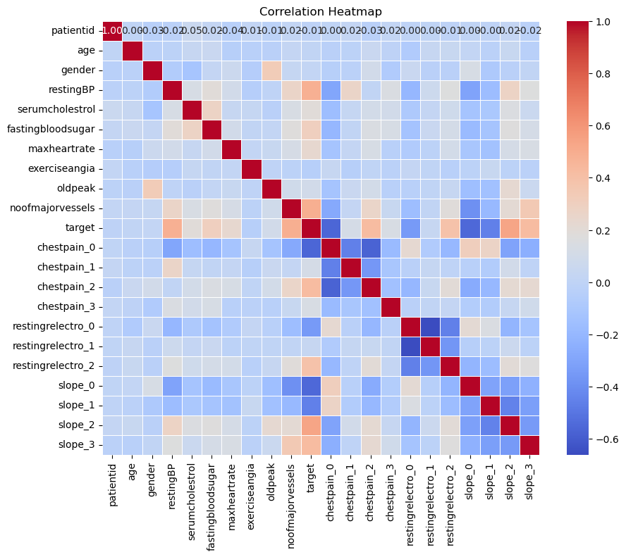

```python
plt.figure(figsize=(10, 8))
correlation_matrix = df.corr()
sns.heatmap(correlation_matrix, annot=True, cmap='coolwarm', fmt='.2f', linewidths=0.5)
plt.title('Correlation Heatmap')
plt.show()
```

### 2. Drop Irrelevant Columns

```python
# Drop 'patientid'
df = df.drop(columns=['patientid'])
```

```python
# Drop 'exerciseangia'
df = df.drop(columns=['exerciseangia'])
```

Keeping the gender and age features in the dataset, even though they have a weak correlation with the target variable. Since my research focuses specifically on the impact of age and gender on cardiovascular disease prediction, it's important to include these variables in the analysis.

Including age and gender will allow us to assess whether they have any meaningful impact on the prediction model and to draw conclusions about their role in predicting cardiovascular disease within the context of my research. After model training, we can evaluate the feature importance and assess the predictive power of these variables, even if their correlation with the target variable is weak.

# Exploratory Data Analysis (EDA)

## Summary statistics for each feature

```python
df.describe().T
```

|  | count | mean | std | min | 25% | 50% | 75% | max |
| --- | --- | --- | --- | --- | --- | --- | --- | --- |
| age | 1000.0 | 0.487367 | 0.297746 | 0.0 | 0.233333 | 0.483333 | 0.737500 | 1.0 |
| gender | 1000.0 | 0.765000 | 0.424211 | 0.0 | 1.000000 | 1.000000 | 1.000000 | 1.0 |
| restingBP | 1000.0 | 0.544783 | 0.282691 | 0.0 | 0.330189 | 0.500000 | 0.820755 | 1.0 |
| serumcholestrol | 1000.0 | 0.517354 | 0.220006 | 0.0 | 0.391611 | 0.528239 | 0.671512 | 1.0 |
| fastingbloodsugar | 1000.0 | 0.296000 | 0.456719 | 0.0 | 0.000000 | 0.000000 | 1.000000 | 1.0 |
| maxheartrate | 1000.0 | 0.568527 | 0.260994 | 0.0 | 0.372137 | 0.572519 | 0.793893 | 1.0 |
| oldpeak | 1000.0 | 0.436726 | 0.277541 | 0.0 | 0.209677 | 0.387097 | 0.661290 | 1.0 |
| noofmajorvessels | 1000.0 | 0.407333 | 0.325862 | 0.0 | 0.000000 | 0.333333 | 0.666667 | 1.0 |
| target | 1000.0 | 0.580000 | 0.493805 | 0.0 | 0.000000 | 1.000000 | 1.000000 | 1.0 |
| chestpain_0 | 1000.0 | 0.420000 | 0.493805 | 0.0 | 0.000000 | 0.000000 | 1.000000 | 1.0 |
| chestpain_1 | 1000.0 | 0.224000 | 0.417131 | 0.0 | 0.000000 | 0.000000 | 0.000000 | 1.0 |
| chestpain_2 | 1000.0 | 0.312000 | 0.463542 | 0.0 | 0.000000 | 0.000000 | 1.000000 | 1.0 |
| chestpain_3 | 1000.0 | 0.044000 | 0.205198 | 0.0 | 0.000000 | 0.000000 | 0.000000 | 1.0 |
| restingrelectro_0 | 1000.0 | 0.454000 | 0.498129 | 0.0 | 0.000000 | 0.000000 | 1.000000 | 1.0 |
| restingrelectro_1 | 1000.0 | 0.344000 | 0.475279 | 0.0 | 0.000000 | 0.000000 | 1.000000 | 1.0 |
| restingrelectro_2 | 1000.0 | 0.202000 | 0.401693 | 0.0 | 0.000000 | 0.000000 | 0.000000 | 1.0 |
| slope_0 | 1000.0 | 0.180000 | 0.384380 | 0.0 | 0.000000 | 0.000000 | 0.000000 | 1.0 |
| slope_1 | 1000.0 | 0.299000 | 0.458049 | 0.0 | 0.000000 | 0.000000 | 1.000000 | 1.0 |
| slope_2 | 1000.0 | 0.322000 | 0.467477 | 0.0 | 0.000000 | 0.000000 | 1.000000 | 1.0 |
| slope_3 | 1000.0 | 0.199000 | 0.399448 | 0.0 | 0.000000 | 0.000000 | 0.000000 | 1.0 |

## Distribution of each numeric feature

Numeric features like: o age o restingBP o serumcholestrol o maxheartrate o oldpeak o noofmajorvessels

## 1. Age

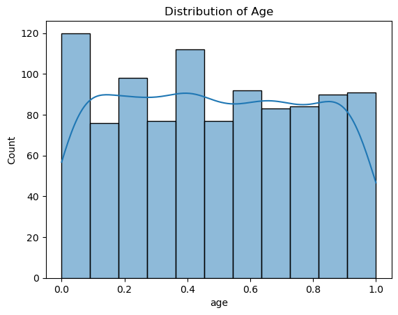

```python
# 'age'
sns.histplot(df['age'], kde=True)
plt.title('Distribution of Age')
plt.show()
```

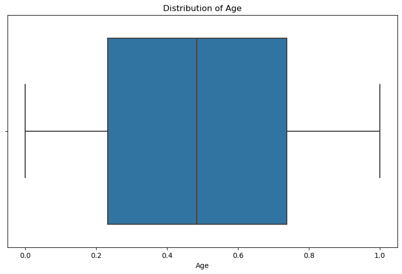

```python
plt.figure(figsize=(10, 6))
sns.boxplot(x='age', data=df)
plt.title('Distribution of Age')
plt.xlabel('Age')
plt.show()
```

## 2. Resting blood pressure

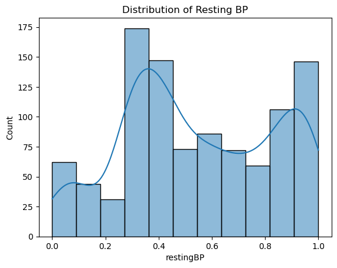

```python
# 'restingBP'
sns.histplot(df['restingBP'], kde=True)
plt.title('Distribution of Resting BP')
plt.show()
```

```python
# Average resting blood pressure among the patients
average_resting_bp = df['restingBP'].mean()
print(f"Average Resting Blood Pressure: {average_resting_bp:.2f} mm Hg")
```

```
Average Resting Blood Pressure: 0.54 mm Hg
```

## 3. Serum cholesterol

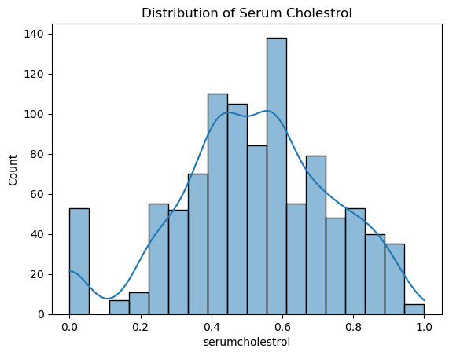

```python
# 'serumcholestrol'
sns.histplot(df['serumcholestrol'], kde=True)
plt.title('Distribution of Serum Cholestrol')
plt.show()
```

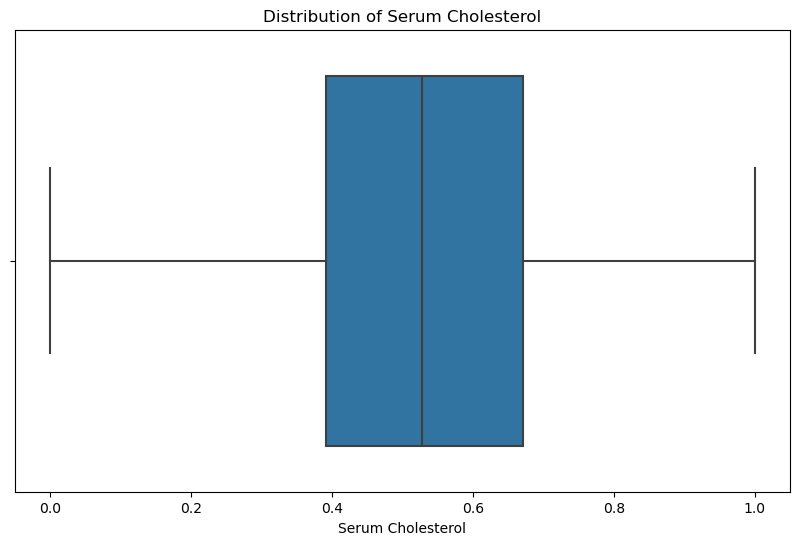

```python
plt.figure(figsize=(10, 6))
sns.boxplot(x='serumcholestrol', data=df)
plt.title('Distribution of Serum Cholesterol')
plt.xlabel('Serum Cholesterol')
plt.show()
```

## 4. Maximum heart rate achieved

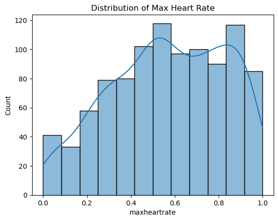

```python
# 'maxheartrate'
sns.histplot(df['maxheartrate'], kde=True)
plt.title('Distribution of Max Heart Rate')
plt.show()
```

```python
# What is the average maximum heart rate achieved by the patients on average?
average_max_heart_rate = df['maxheartrate'].mean()
print(f"Average Maximum Heart Rate: {average_max_heart_rate:.2f}")
```

```
Average Maximum Heart Rate: 0.57
```

## 5. Oldpeak =ST

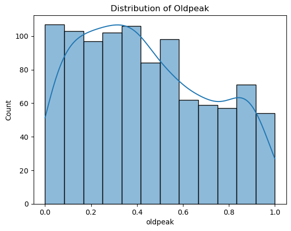

```python
# 'oldpeak'
sns.histplot(df['oldpeak'], kde=True)
plt.title('Distribution of Oldpeak')
plt.show()
```

```python
# What is the average oldpeak (ST depression induced by exercise relative to rest) among the patients?
average_oldpeak = df['oldpeak'].mean()
print(f"Average Oldpeak: {average_oldpeak:.2f}")
```

```
Average Oldpeak: 0.44
```

## 6. Number of major vessels

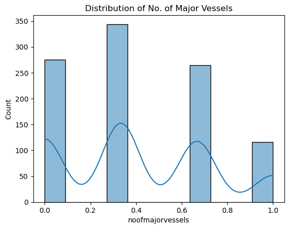

```python
# 'noofmajorvessels'
sns.histplot(df['noofmajorvessels'], kde=True)
plt.title('Distribution of No. of Major Vessels')
plt.show()
```

```python
# What is the range of the number of major vessels in the patients?
vessels_range = f"Number of Major Vessels Range: {df['noofmajorvessels'].min()} - {df['noofmajorvessels'].max()}"
print(vessels_range)
```

```
Number of Major Vessels Range: 0.0 - 1.0
```

```python
# How many patients have all three major vessels showing defects?
defects_count = len(df[df['noofmajorvessels'] == 3])
print(f"Number of Patients with Defects in All Three Major Vessels: {defects_count}")
```

[output not shown]

## Distribution of each binary or nominal feature

Binary or nominal feature like: o gender o chestpain o fastingbloodsugar o exerciseangia o restingrelectro o slope

## 7. Gender

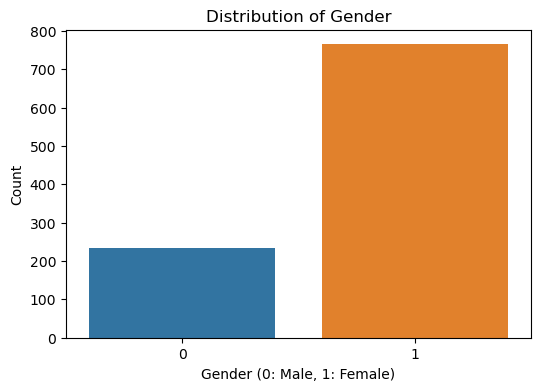

```python
# Count plot for gender
plt.figure(figsize=(6, 4))
sns.countplot(x='gender', data=df)
plt.title('Distribution of Gender')
plt.xlabel('Gender (0: Male, 1: Female)')
plt.ylabel('Count')
plt.show()
```

```python
gender_count = df['gender'].value_counts()
print(gender_count)
```

```
gender
1    765
0    235
Name: count, dtype: int64
```

## 8. Chest pain type

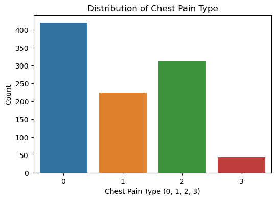

```python
# Count plot for chestpain
''' Value 0: typical angina
    Value 1: atypical angina
    Value 2: non-anginal pain
    Value 3: asymptomatic '''

# Create a new column for chest pain type by taking the argmax of the one-hot encoded columns
df['chestpain'] = df[['chestpain_0', 'chestpain_1', 'chestpain_2', 'chestpain_3']].idxmax(axis=1).apply(lambda x: int(x.split('_')[1]))

# Now plot the count plot using the new 'chestpain' column
plt.figure(figsize=(6, 4))
sns.countplot(x='chestpain', data=df)
plt.title('Distribution of Chest Pain Type')
plt.xlabel('Chest Pain Type (0, 1, 2, 3)')
plt.ylabel('Count')
plt.show()
```

```python
print(df['chestpain'].unique())
print(df['chestpain'].value_counts())
chest = {
    0: "typical angina",
    1: "atypical angina",
    2: "non-anginal pain",
    3: "asymptomatic"
}
```

```
[2 0 1 3]
chestpain
0    420
2    312
1    224
3     44
Name: count, dtype: int64
```

```python
def PiePlot(column):
    '''
    Parameters:
    -column(Optional): column in df to be visualized
    -shadow(Optional): Apply shadow effect on pie chart

    '''
    plt.figure(figsize=(12,6))
    plt.pie(df[column].value_counts(), labels = df[column].value_counts().index, autopct = "%1.1f%%")
    plt.title(f'Pie Chart of {column}')
    plt.show()
```

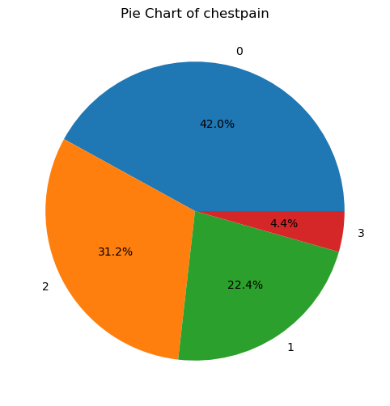

```
Type 0 is typical angina
Type 1 is atypical angina
Type 2 is non-anginal pain
Type 3 is asymptomatic
```

```python
chest = {
    0: "typical angina",
    1: "atypical angina",
    2: "non-anginal pain",
    3: "asymptomatic"
}
PiePlot('chestpain')
for i in np.sort(df['chestpain'].unique()):
    print(f'Type {i} is {chest[i]}')
```

## 9. Fasting blood sugar

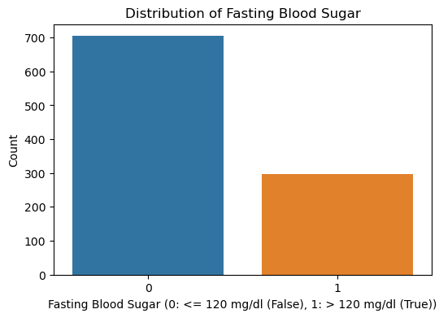

```python
# Count plot for fastingbloodsugar
plt.figure(figsize=(6, 4))
sns.countplot(x='fastingbloodsugar', data=df)
plt.title('Distribution of Fasting Blood Sugar')
plt.xlabel('Fasting Blood Sugar (0: <= 120 mg/dl (False), 1: > 120 mg/dl (True))') # 0,1 > 120 mg/dl (0 = false , 1 = true)
plt.ylabel('Count')
plt.show()
```

```python
fastingbloodsugar = df['fastingbloodsugar'].value_counts()
print(fastingbloodsugar)
```

```
fastingbloodsugar
0    704
1    296
Name: count, dtype: int64
```

```python
# What percentage of patients have fasting blood sugar greater than 120 mg/dl?
percentage_high_fasting_sugar = (df['fastingbloodsugar'].sum() / len(df)) * 100
print(f"Percentage of patients with fasting blood sugar > 120 mg/dl: {percentage_high_fasting_sugar:.2f}%")
```

```
Percentage of patients with fasting blood sugar > 120 mg/dl: 29.60%
```

## 10. Resting Electrocardiographic Results

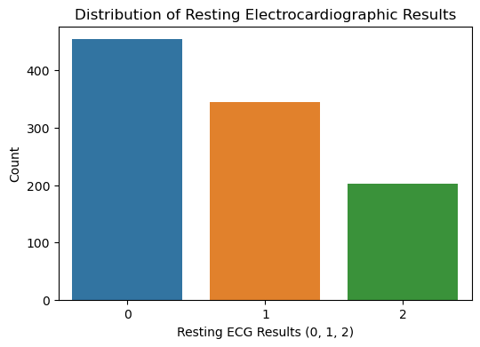

```python
# Count plot for restingrelectro
'''
Value 0: normal,
Value 1: having ST-T wave abnormality (T wave inversions and/or ST elevation or depression of > 0.05 mV),
Value 2: showing probable or definite left ventricular hypertrophy by Estes'criteria
'''
# 'restingrelectro_0', 'restingrelectro_1', 'restingrelectro_2' are the one-hot encoded columns
# Combine these columns into a single 'restingrelectro' column with their respective values

df['restingrelectro'] = df[['restingrelectro_0', 'restingrelectro_1', 'restingrelectro_2']].idxmax(axis=1).apply(lambda x: int(x.split('_')[1]))

# Now plot the count plot using the new 'restingrelectro' column
plt.figure(figsize=(6, 4))
sns.countplot(x='restingrelectro', data=df)
plt.title('Distribution of Resting Electrocardiographic Results')
plt.xlabel('Resting ECG Results (0, 1, 2)')
plt.ylabel('Count')
plt.show()
```

```python
# What are the predominant resting electrocardiogram results in the dataset?
resting_electro_counts = df['restingrelectro'].value_counts()
print(resting_electro_counts)
```

```
restingrelectro
0    454
1    344
2    202
Name: count, dtype: int64
```

## 12. Slope of Peak Exercise ST Segment

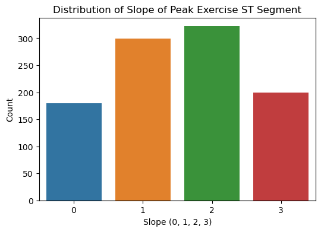

```python
# Count plot for slope
# Combine the one-hot encoded slope columns into a single 'slope' column
df['slope'] = df[['slope_0', 'slope_1', 'slope_2', 'slope_3']].idxmax(axis=1).apply(lambda x: int(x.split('_')[1]))

# Now plot the count plot using the new 'slope' column
plt.figure(figsize=(6, 4))
sns.countplot(x='slope', data=df)
plt.title('Distribution of Slope of Peak Exercise ST Segment')
plt.xlabel('Slope (0, 1, 2, 3)') # 1, 2, 3 (1-upsloping, 2-flat, 3-downsloping)
plt.ylabel('Count')
plt.show()
```

```python
# What percentage of patients in the dataset have heart disease (target = 1)?
percentage_heart_disease = (df['target'].sum() / len(df)) * 100
print(f"Percentage of Patients with Heart Disease: {percentage_heart_disease:.2f}%")
```

```
Percentage of Patients with Heart Disease: 58.00%
```

## Age Distribution by Gender

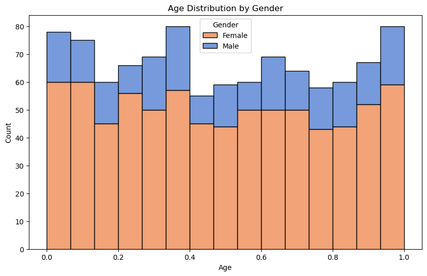

```python
# Age Distribution by Gender:
plt.figure(figsize=(10, 6))
sns.histplot(x='age', hue='gender', data=df, palette='muted', multiple='stack', bins=15)
plt.title('Age Distribution by Gender')
plt.xlabel('Age')
plt.ylabel('Count')
plt.legend(title='Gender', labels=['Female', 'Male'])
plt.show()
```

## Correlation between age and maximum heart rate

```python
correlation_age_maxheartrate = df['age'].corr(df['maxheartrate'])
print(f"Correlation between Age and Maximum Heart Rate: {correlation_age_maxheartrate:.2f}")
```

```
Correlation between Age and Maximum Heart Rate: -0.04
```

## Relationship between chest pain type and the presence of heart disease

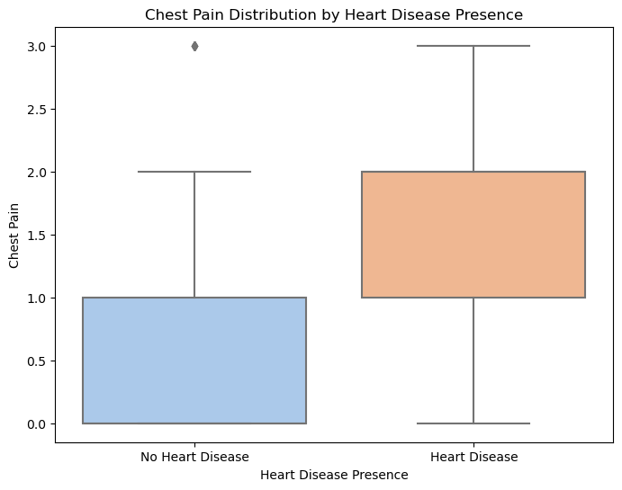

```python
# box plot for chest pain type vs heart disease
plt.figure(figsize=(8, 6))
sns.boxplot(x='target', y='chestpain', data=df, palette='pastel')
plt.title('Chest Pain Distribution by Heart Disease Presence')
plt.xlabel('Heart Disease Presence')
plt.ylabel('Chest Pain')
plt.xticks(ticks=[0, 1], labels=['No Heart Disease', 'Heart Disease'])
plt.show()
```

## How does serum cholesterol differ between patients with and without heart disease?

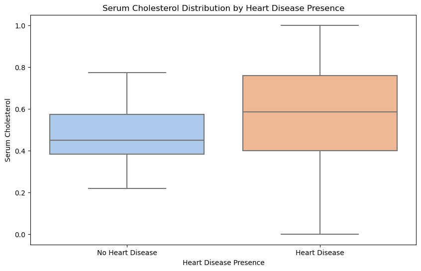

```python
plt.figure(figsize=(10, 6))
sns.boxplot(x='target', y='serumcholestrol', data=df, palette='pastel')
plt.title('Serum Cholesterol Distribution by Heart Disease Presence')
plt.xlabel('Heart Disease Presence')
plt.ylabel('Serum Cholesterol')
plt.xticks(ticks=[0, 1], labels=['No Heart Disease', 'Heart Disease'])
plt.show()
```

## What is the distribution of oldpeak values for patients with heart disease

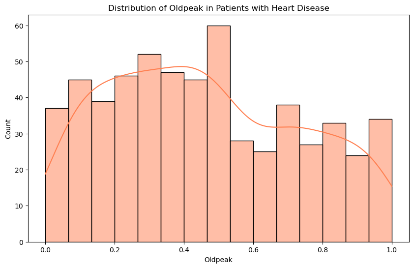

```python
plt.figure(figsize=(10, 6))
sns.histplot(x='oldpeak', data=df[df['target'] == 1], bins=15, kde=True, color='coral')
plt.title('Distribution of Oldpeak in Patients with Heart Disease')
plt.xlabel('Oldpeak')
plt.ylabel('Count')
plt.show()
```

## Max Heart Rate by Gender and Heart Disease Presence

```
               count      mean       std       min       25%       50%  \
gender target
0      0       102.0  0.515716  0.282708  0.000000  0.309160  0.492366
       1       133.0  0.555300  0.264015  0.190840  0.297710  0.557252
1      0       318.0  0.493015  0.305158  0.000000  0.229008  0.465649
       1       447.0  0.638233  0.195029  0.259542  0.507634  0.633588

                    75%       max
gender target
0      0       0.751908  1.000000
       1       0.832061  0.969466
1      0       0.770992  1.000000
       1       0.793893  1.000000
```

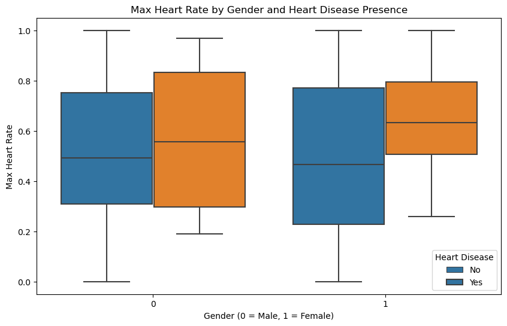

```python
# Ensure 'gender' and 'target' (Heart Disease) are categorical for analysis
df['gender'] = df['gender'].astype('category')
df['target'] = df['target'].astype('category')

# Group by Gender and Heart Disease presence and calculate mean, median, and max heart rate statistics
max_hr_stats = df.groupby(['gender', 'target'])['maxheartrate'].describe()
print(max_hr_stats)

# Boxplot to visualize Max Heart Rate by Gender and Heart Disease presence
plt.figure(figsize=(10, 6))
sns.boxplot(x='gender', y='maxheartrate', hue='target', data=df)
plt.title('Max Heart Rate by Gender and Heart Disease Presence')
plt.xlabel('Gender (0 = Male, 1 = Female)')
plt.ylabel('Max Heart Rate')
plt.legend(title='Heart Disease', labels=['No', 'Yes'])
plt.show()
```

# Bivariate Analysis

## Age vs Target (Heart Disease Presence)

```python
# Calculate summary statistics for Age based on Heart Disease (Target)
age_stats = df.groupby('target')['age'].describe()
print(age_stats)
```

```
        count      mean       std  min   25%       50%       75%  max
target
0       420.0  0.484444  0.311743  0.0  0.20  0.483333  0.766667  1.0
1       580.0  0.489483  0.287439  0.0  0.25  0.483333  0.716667  1.0
```

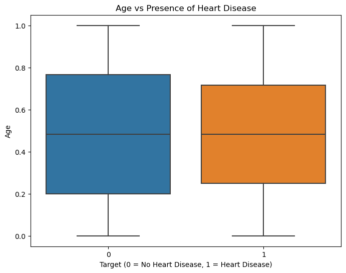

```python
# Boxplot to compare Age distribution between Heart Disease presence (0 = No, 1 = Yes)
plt.figure(figsize=(8, 6))
sns.boxplot(x='target', y='age', data=df)
plt.title('Age vs Presence of Heart Disease')
plt.xlabel('Target (0 = No Heart Disease, 1 = Heart Disease)')
plt.ylabel('Age')
plt.show()
```

## Age vs Gender

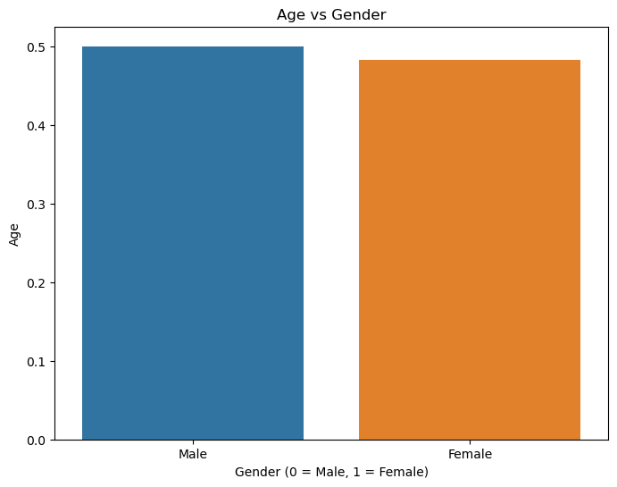

```python
# Barplot to show the relationship between Age and Gender
plt.figure(figsize=(8, 6))
sns.barplot(x='gender', y='age', data=df, ci=None)
plt.title('Age vs Gender')
plt.xlabel('Gender (0 = Male, 1 = Female)')
plt.ylabel('Age')
plt.xticks([0, 1], ['Male', 'Female'])
plt.show()
```

## Age vs Chest Pain Type

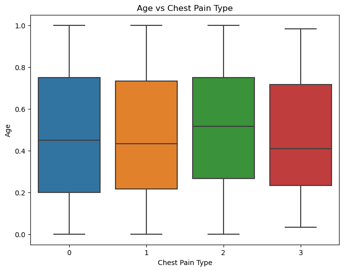

```python
# Boxplot to show the relationship between Age and Chest Pain Type
plt.figure(figsize=(8, 6))
sns.boxplot(x='chestpain', y='age', data=df)
plt.title('Age vs Chest Pain Type')
plt.xlabel('Chest Pain Type')
plt.ylabel('Age')
plt.show()
```

## Age vs Fasting Blood Sugar

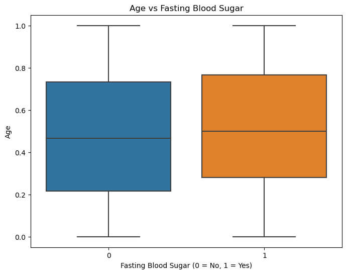

```python
# Boxplot to show the relationship between Age and Fasting Blood Sugar
plt.figure(figsize=(8, 6))
sns.boxplot(x='fastingbloodsugar', y='age', data=df)
plt.title('Age vs Fasting Blood Sugar')
plt.xlabel('Fasting Blood Sugar (0 = No, 1 = Yes)')
plt.ylabel('Age')
plt.show()
```

## Gender Distribution for Heart Disease Presence

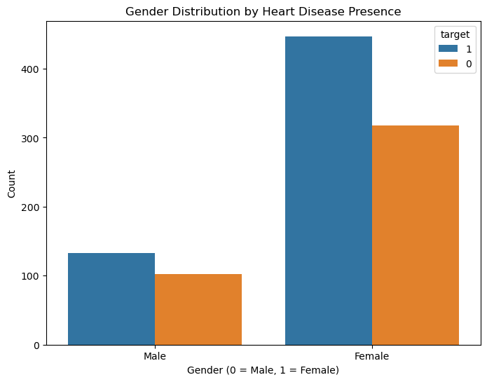

```python
# convert to string if you'd like to see '0' and '1' as labels
df1 = df.copy()
df1['target'] = df1['target'].astype(str)

# Countplot to show the relationship between Gender and Heart Disease Presence
plt.figure(figsize=(8, 6))
sns.countplot(x='gender', hue='target', data=df1)
plt.title('Gender Distribution by Heart Disease Presence')
plt.xlabel('Gender (0 = Male, 1 = Female)')
plt.ylabel('Count')
plt.xticks([0, 1], ['Male', 'Female'])
plt.show()
```

# Multivariate Analysis

## Age vs Gender and Heart Disease Presence

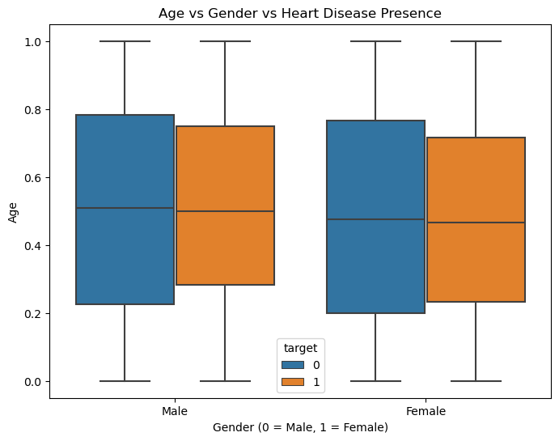

```python
# Boxplot to show the relationship between Age, Gender, and Heart Disease Presence
plt.figure(figsize=(8, 6))
sns.boxplot(x='gender', y='age', hue='target', data=df)
plt.title('Age vs Gender vs Heart Disease Presence')
plt.xlabel('Gender (0 = Male, 1 = Female)')
plt.ylabel('Age')
plt.xticks([0, 1], ['Male', 'Female'])
plt.show()
```

## Max Heart Rate by Gender and Heart Disease Presence

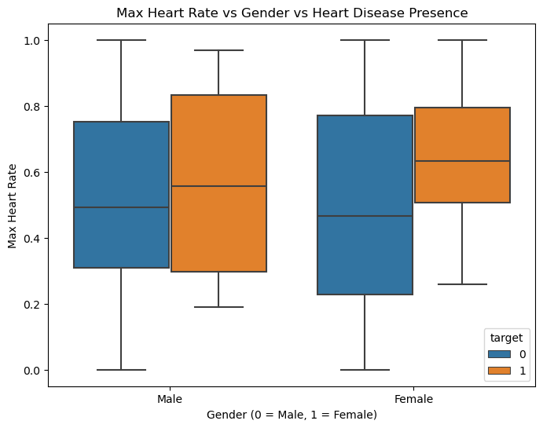

```python
# Boxplot to show the relationship between Max Heart Rate, Gender, and Heart Disease
plt.figure(figsize=(8, 6))
sns.boxplot(x='gender', y='maxheartrate', hue='target', data=df)
plt.title('Max Heart Rate vs Gender vs Heart Disease Presence')
plt.xlabel('Gender (0 = Male, 1 = Female)')
plt.ylabel('Max Heart Rate')
plt.xticks([0, 1], ['Male', 'Female'])
plt.show()
```

## Age vs Gender Distribution for Different Chest Pain Types

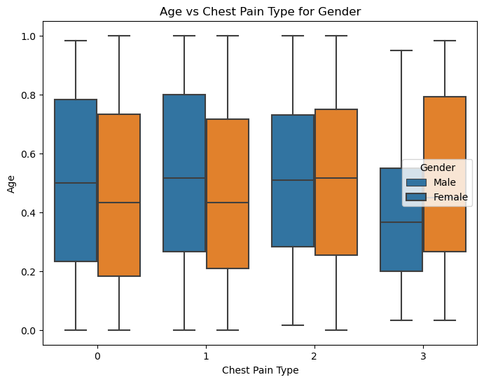

```python
# Boxplot to show Age vs Chest Pain Type for Males and Females
plt.figure(figsize=(8, 6))
sns.boxplot(x='chestpain', y='age', hue='gender', data=df)
plt.title('Age vs Chest Pain Type for Gender')
plt.xlabel('Chest Pain Type')
plt.ylabel('Age')
plt.legend(title='Gender', labels=['Male', 'Female'])
plt.show()
```

## Visualization for Resting blood pressure, Serum cholesterol, Maximum heart rate achieved and Oldpeak (ST)

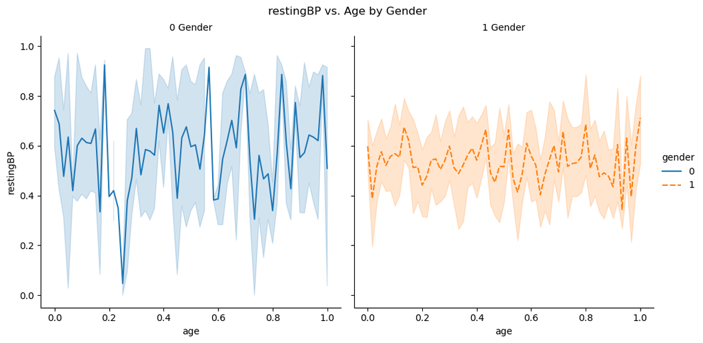

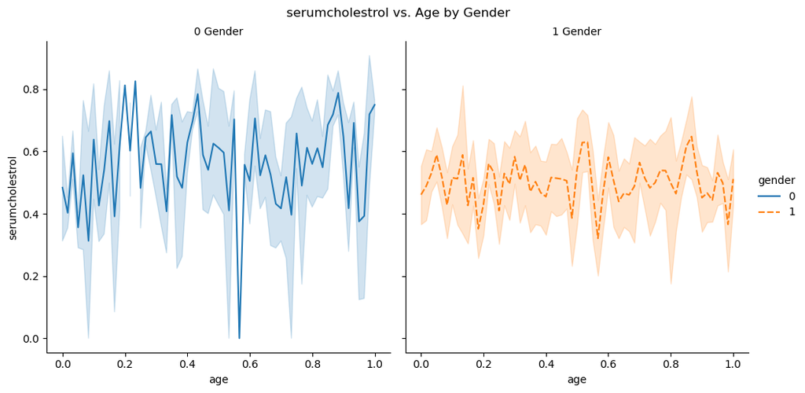

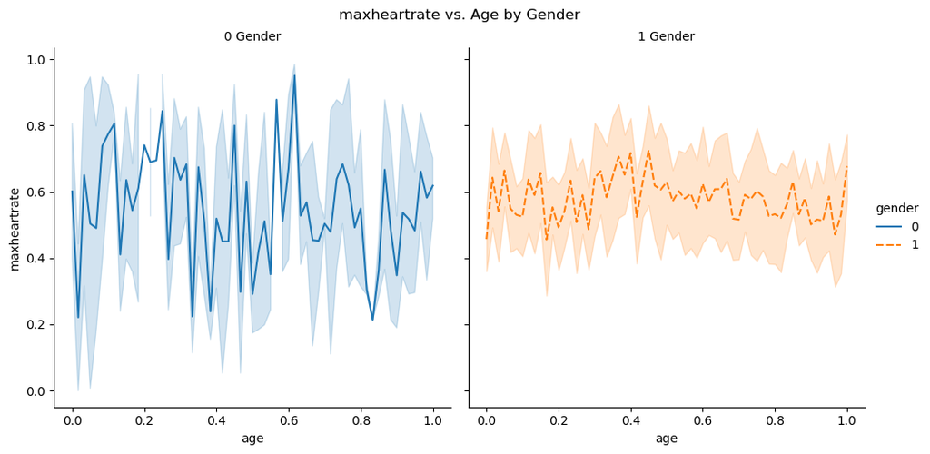

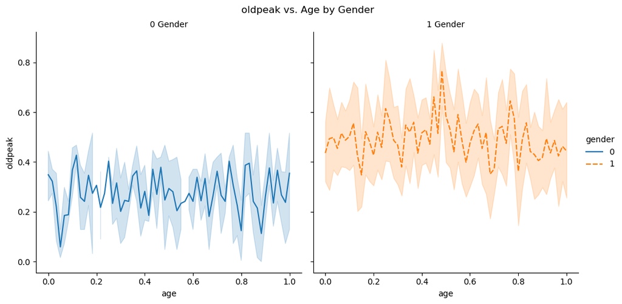

```python
numeric_cols = ['restingBP', 'serumcholestrol', 'maxheartrate', 'oldpeak']
gender = {0: 'Male', 1: 'Female'}  # Gender dictionary (needed for mapping)

for i in numeric_cols:
    plt.figure(figsize=(20, 12))

    # Using sns.relplot with 'gender' as hue
    plot = sns.relplot(data=df, x='age', y=i, kind='line', hue='gender', style='gender', col='gender')

    # Set the title for each subplot
    plot.set_titles("{col_name} Gender")

    # Add a main title outside the plot
    plt.suptitle(f"{i} vs. Age by Gender", y=1.02)

    # Show the plot
    plt.show()
```

```python
df['gender'].value_counts()
```

```
gender
1    765
0    235
Name: count, dtype: int64
```